# QUICK DATA EXPLORATION BY R.MLEARNING

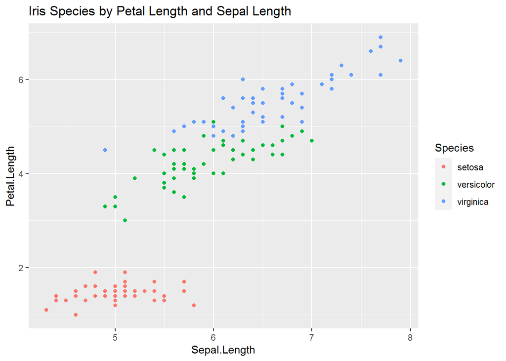

```r
ggplot(iris, aes(x = Sepal.Length, y = Petal.Length, colour = Species)) +
  geom_point() +
  ggtitle('Iris Species by Petal Length and Sepal Length')
```

8. Again use GGPLOT, a standard library for data visualisation. Lets look at how data varies between Petal Width and Sepal Width

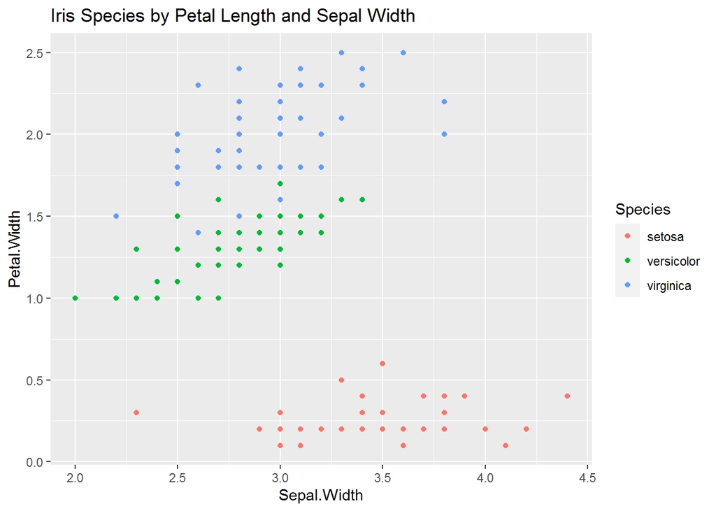

```r
ggplot(iris, aes(x = Sepal.Width, y = Petal.Width, colour = Species)) +
  geom_point() +
  ggtitle('Iris Species by Petal Length and Sepal Width')
```

9. LINEAR REG - lets perform linear regression.

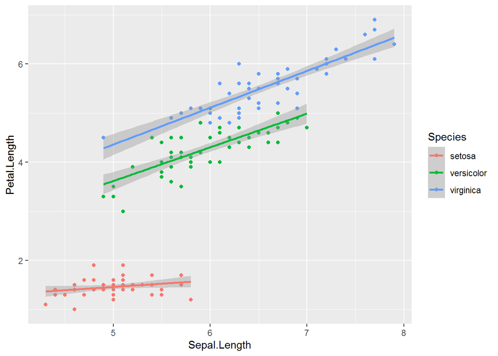

```r
#linear reg
ggplot(iris, aes(x=Sepal.Length, y=Petal.Length, color=Species)) +
  geom_point()+geom_smooth(method = "lm")
```

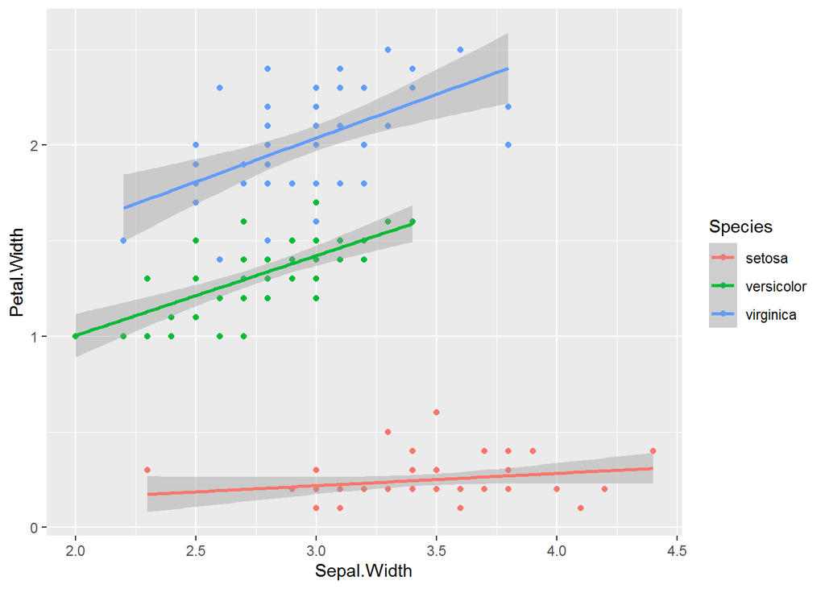

```r
#linear reg
ggplot(iris, aes(x=Sepal.Width, y=Petal.Width,  color=Species)) +
  geom_point()+geom_smooth(method = "lm")
```

AND THAT WOULD BE IT!! This is just a beginner project, so only basic is covered, which is already presented on my

INSTAGRAM PAGE - [R.MLEARNING][instagram.com/r.mlearning]

For more project stay tuned….